# Kharal_5

Importing necesscary Libraries

[output not shown]

[output not shown]

[output not shown]

[output not shown]

```
Archive:  fertilizer-recommendation.zip
  inflating: ./data/fertilizer_recommendation_dataset.csv
```

# Performing EDA

```
<class 'pandas.core.frame.DataFrame'>
RangeIndex: 3100 entries, 0 to 3099
Data columns (total 12 columns):
 #   Column       Non-Null Count  Dtype
---  ------       --------------  -----
 0   Temperature  3100 non-null   float64
 1   Moisture     3100 non-null   float64
 2   Rainfall     3100 non-null   float64
 3   PH           3100 non-null   float64
 4   Nitrogen     3100 non-null   float64
 5   Phosphorous  3100 non-null   float64
 6   Potassium    3100 non-null   float64
 7   Carbon       3100 non-null   float64
 8   Soil         3100 non-null   object
 9   Crop         3100 non-null   object
 10  Fertilizer   3100 non-null   object
 11  Remark       3100 non-null   object
dtypes: float64(8), object(4)
memory usage: 290.8+ KB
```

From this output, we can infer the following:

- There are no null values in the dataset.
- There are eight numerical datatypes with four object datatypes.
- The name of the Features present in the dataset are as follows:

  Temperature, Moisture, Rainfall, PH, Nitrogen, Phosporous, Potassium, Carbon, Soil, Crop, Fertilizer, Remarks

Next, We will look at some of the values from this data and try to infer what sort of data there is.

|  | Temperature | Moisture | Rainfall | PH | Nitrogen | Phosphorous | Potassium | Carbon | Soil | Crop | Fertilizer | Remark |
| --- | --- | --- | --- | --- | --- | --- | --- | --- | --- | --- | --- | --- |
| 0 | 50.179845 | 0.725893 | 205.600816 | 6.227358 | 66.701872 | 76.963560 | 96.429065 | 0.496300 | Loamy Soil | rice | Compost | Enhances organic matter and improves soil stru... |
| 1 | 21.633318 | 0.721958 | 306.081601 | 7.173131 | 71.583316 | 163.057636 | 148.128347 | 1.234242 | Loamy Soil | rice | Balanced NPK Fertilizer | Provides a balanced mix of nitrogen, phosphoru... |
| 2 | 23.060964 | 0.685751 | 259.336414 | 7.380793 | 75.709830 | 62.091508 | 80.308971 | 1.795650 | Peaty Soil | rice | Water Retaining Fertilizer | Improves water retention in dry soils. Prefer ... |
| 3 | 26.241975 | 0.755095 | 212.703513 | 6.883367 | 78.033687 | 151.012521 | 153.005712 | 1.517556 | Loamy Soil | rice | Balanced NPK Fertilizer | Provides a balanced mix of nitrogen, phosphoru... |
| 4 | 21.490157 | 0.730672 | 268.786767 | 7.578760 | 71.765123 | 66.257371 | 97.000886 | 1.782985 | Peaty Soil | rice | Organic Fertilizer | Enhances fertility naturally, ideal for peaty ... |

From the first five values we find that Temperature, Moisture, Rainfall, PH, Nitrogen, Phosporous, Potassium and Carbon are numerical(continous) values which tell us about the environment in which the crop was grown.

Soil is a categorical(discrete) variable that tells about the type of the soil the crop was grown in.

Crop and Fertilizer are also categorical values that tell us about what we planted and also what kind of fertilizer we gave those crops.

Remark is a string feature that tells us about the effect the fertilizer had on the crop.

From this data following questions may raise in the stake-holders mind and we will try to answer most of those questions and also create a model that will be able to predict optimal conditions for each crop to grow as well as recommend fertilizer according to the environment.

Following are the questions we will address:

- Is there a correlation between the numerical values in the dataset?
- What is the data distribution of the numerical values.
- Which fertilizer has in average; good remarks compared to other?
- Which fertilizer is used the most on which crop.
- Does the kind of soil affect the effectiveness of the fertilizers

**Question: Correlation bettwen numerical values**:

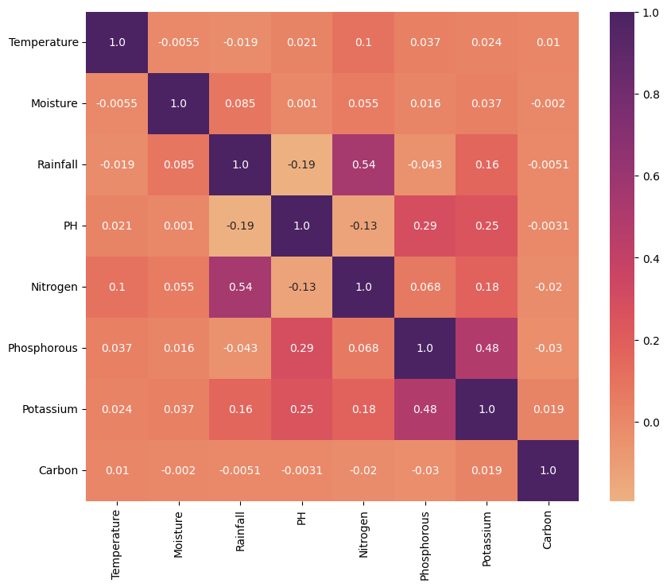

Here we can see that there is some correlation between nitrogen and rain fall.

We also see some co-relation between Potassium and Phosphorous. This may be becuase of similar geological origins.

PH also has some positve corelation with Potassium and phoshorous, and it also has negative correlation with nitrogen.

We can hypothesize the reason of co relation between PH level and the elements being how the elements react with water and is absorbed up by plants. Nitrogen in fertilzers react to increase acidity of the soil while potassium and phosphorous will increase the PH-level of the soil.

We can hypothesize that the carbon is present as the by-product of the breakdown of fertilizers and also being in general, the part of the earth.

We do not see a strong co-relation between rainfall and moisture as one would assume. I can not make an observation regarding this.

**Descriptive statistical analysis of the data**:

|  | count | mean | std | min | 25% | 50% | 75% | max |
| --- | --- | --- | --- | --- | --- | --- | --- | --- |
| Temperature | 3100.0 | 27.271096 | 9.114450 | 4.011486 | 22.408505 | 26.132938 | 29.987887 | 56.653592 |
| Moisture | 3100.0 | 0.600763 | 0.144947 | 0.227436 | 0.493595 | 0.599520 | 0.708575 | 0.972361 |
| Rainfall | 3100.0 | 111.024949 | 77.151880 | -85.709593 | 61.283985 | 96.485935 | 147.619401 | 411.955947 |
| PH | 3100.0 | 6.379775 | 0.957103 | 3.448974 | 5.860489 | 6.337308 | 6.899739 | 9.562341 |
| Nitrogen | 3100.0 | 61.278480 | 10.186410 | 35.527718 | 54.835715 | 59.429649 | 65.792790 | 98.581039 |
| Phosphorous | 3100.0 | 69.582850 | 42.226712 | -37.649739 | 43.039260 | 58.205269 | 86.108983 | 177.314481 |
| Potassium | 3100.0 | 69.721167 | 35.304241 | -20.509108 | 49.992405 | 58.710808 | 76.318626 | 161.067982 |
| Carbon | 3100.0 | 1.474325 | 0.698300 | -0.280560 | 0.956401 | 1.463357 | 2.003534 | 3.241984 |

Here we can see the minimum, maximum and average values for the numerical columns,

For temperature, the average was 27 ${\degree} C$, while the lowest and the highest was 4 ${\degree} C$ and 56.6 ${\degree} C$ respectively.

On average the rainfall we got was 111 $mm^2$